# Predicting Graduate Admission

##### Plotting Histogram with Comparing Average GRE_Score with Median GRE_Score value

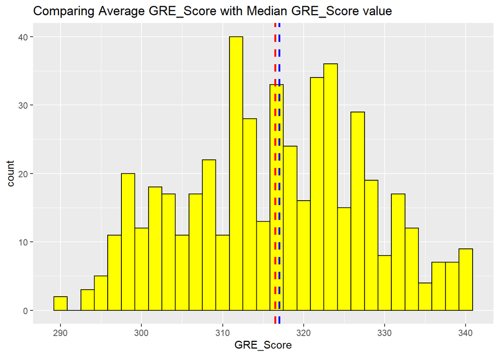

```r
ggplot(graduate_admission.fac, aes(x = GRE_Score))  +
  geom_histogram(fill = 'yellow', colour = 'black', binwidth = 1.666667) +
  geom_vline(xintercept = mean(graduate_admission.fac$GRE_Score), linetype = "dashed", colour = 'red', size = 1) + geom_vline(xintercept = median(graduate_admission.fac$GRE_Score), linetype = "dashed", colour = 'blue', size = 1) +
  ggtitle("Comparing Average GRE_Score with Median GRE_Score value")
```

> Shape and Skewness of the distribution

—- The above plot is showing that Mean value(that is average GRE_Score) is smaller than the Median Value that we expect for the Left skewed distribution and shape is Multimodal.

> Central Tendency

—- It would be better to use the median as a measure of central tendency given that the distribution is skewed. We know that the median is more robust to outliers than the mean so this should give us a better sense of the centre of the data distribution.

> Measure of Spread

– Finding IQR

```r
IQR(graduate_admission.fac$GRE_Score)
```

```
## [1] 17
```

– Finding Standerd Deviation

```r
sd(graduate_admission.fac$GRE_Score)
```

```
## [1] 11.29515
```

We should use the interquartile range as a measure of spread since it is a more robust measure than standard deviation in the presence of skewness/ outliers.

##### Visualising GRE_Score with Chance_of_Admit

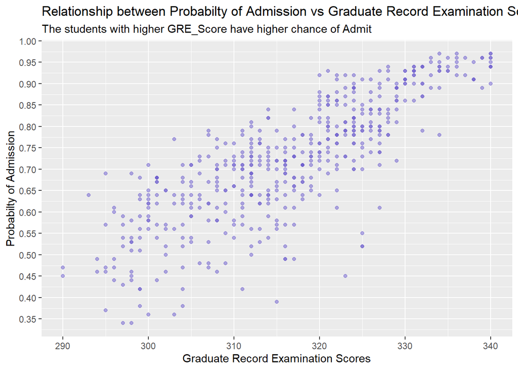

```r
ggplot(graduate_admission.fac, aes(x = GRE_Score, y = Chance_of_Admit)) +
  geom_point(alpha = 0.5, col='slateblue') +
  scale_y_continuous(breaks = seq(0,1, by = 0.05)) +
  xlab("Graduate Record Examination Scores") +
  ylab("Probabilty of Admission") +
  ggtitle("Relationship between Probabilty of Admission vs Graduate Record Examination Scores",
          subtitle = "The students with higher GRE_Score have higher chance of Admit")
```

##### Plotting Scatter Plot of GRE_Score vs Chance_of_Admit with a trend line that is the best fit line for the given relationship

[figure not shown]

```r
ggplot(graduate_admission.fac, aes(GRE_Score, Chance_of_Admit)) +
  geom_point(alpha = 0.5, col='slateblue') +
  geom_smooth(se = FALSE, color = "red", method = "lm") +
  scale_y_continuous(breaks = seq(0,1, by = 0.05)) +
  scale_x_continuous(breaks = seq(5,10, by = 0.5)) +
  xlab("Cumulative Grade Point Average") +
  ylab("Probabilty of Admission") +
  ggtitle("Probabilty of Admission vs Cumulative Grade Point Average",
          subtitle = "The students with higher GRE_Score have higher chance of Admit shown with a trend line")
```

> The form, direction, and strength of the observed relationship that is GRE_Score vs Chance_of_Admit.

—- It appears that Chance_of_Admit has a Positive, linear relation with the GRE_Score (or at least could potentially be modeled as such) and appears to be somewhat of a fairly strong relationship. As it is said that with higher scores there is a higher chance of getting a admit from good University.

—- The value of the correlation coefficient is on the stronger side, confirming what we see in the plot.

```r
cor(graduate_admission.fac$Chance_of_Admit, graduate_admission.fac$GRE_Score)
```

```
## [1] 0.8103506
```

– We have already checked the correlation coefficient of all the variables, in the starting of our project and then selected the one which has the higest correlation coefficient which we have proved here again by performing Bivariate Analysis.

– Till now our Hypothesis is going right with the above facts.

### Preforming Linear model

##### Using a scatter plot to display the relationship between Chance_of_Admit and GRE_Score.

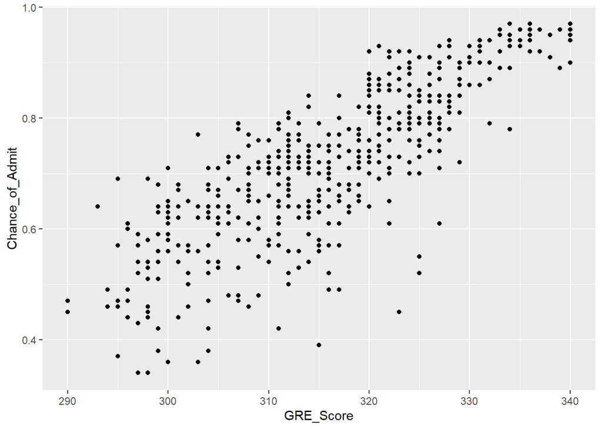

```r
ggplot(graduate_admission.fac, aes(GRE_Score, Chance_of_Admit)) +
  geom_point()
```

–The relationship looks linear.

–I would feel comfortable using a linear model to predict the number of Chance_of_Admit. It’s not a perfect relationship but it seems like it would do a pretty good job predicting Chance_of_Admit from GRE_Score.

– If the relationship looks linear, we can quantify the strength of the relationship with the correlation coefficient.

```r
cor(graduate_admission.fac$Chance_of_Admit, graduate_admission.fac$GRE_Score)
```

```
## [1] 0.8103506
```

##### Creating Linear Model for Chance_of_Admit ~ GRE_Score

```r
m2 <- lm(Chance_of_Admit ~ GRE_Score, data = graduate_admission.fac)
```

##### Summary of Linear Model m2

```r
summary(m2)
```

```
##
## Call:
## lm(formula = Chance_of_Admit ~ GRE_Score, data = graduate_admission.fac)
##
## Residuals:
##      Min       1Q   Median       3Q      Max
## -0.33784 -0.04479  0.00417  0.05449  0.18568
##
## Coefficients:
##               Estimate Std. Error t value Pr(>|t|)
## (Intercept) -2.4828147  0.1038994  -23.90   <2e-16 ***
## GRE_Score    0.0101259  0.0003281   30.86   <2e-16 ***
## ---
## Signif. codes:  0 '***' 0.001 '**' 0.01 '*' 0.05 '.' 0.1 ' ' 1
##
## Residual standard error: 0.08278 on 498 degrees of freedom
## Multiple R-squared:  0.6567, Adjusted R-squared:  0.656
## F-statistic: 952.5 on 1 and 498 DF,  p-value: < 2.2e-16
```

> The slope for the linear model (from least squares algotithm using the lm() function) is 0.0101259 the intercept for the linear model is -2.4828147

> The least squares regression line for Chance_of_Admit vs GRE_Score for the linear model:

$$\hat{y} = -2.4828147 + 0.0101259 * GREScore$$

> Slope of 0.0101259 tells us that for every “GRE_Score”, on average, a student will have 0.0101259 more “Chance_of_Admit”. This would imply that a student with more GRE Score is more likely to be successful scince the student would be more likly to have a Chance of Admit in a good university

##### Prediction and prediction errors

> If a student saw the least squares regression line and not the actual data, how student will predict the Chance of Admit for a GRE Score of 320? Is this an overestimate or an underestimate, and by how much? In other words, what is the residual for this prediction?

– The student will predict -2.4828147 + 0.0101259*GREScore Chance_of_Admit

– To calculate a residual we use the formula: ei=yi−y^i, where
$$y_i$$
is the actual value from the data and y^i is the corresponding value predicted by our linear model.

> Predicted value for Chance of Admit where GRE_Score = 320

```r
pred_COA_GREScore <- -2.4828147 + 0.0101259*320
pred_COA_GREScore
```

```
## [1] 0.7574733
```

> To Calculate the actual Chance of Admit we will filter students with GRE_Score = 320

```r
GREScore_320 <- graduate_admission.fac %>% filter(GRE_Score == 320)
GREScore_320
```

| GRE_Score | TOEFL_Score | University_Rating | SOP | LOR | CGPA | Research | Chance_of_Admit |
| --- | --- | --- | --- | --- | --- | --- | --- |
| 320 | 110 | 5 | 5 | 5 | 9.20 | 1 | 0.88 |
| 320 | 103 | 3 | 3 | 3 | 7.70 | 0 | 0.64 |
| 320 | 110 | 5 | 5 | 4.5 | 9.22 | 1 | 0.92 |
| 320 | 110 | 2 | 4 | 3.5 | 8.56 | 0 | 0.72 |
| 320 | 113 | 2 | 2 | 2.5 | 8.64 | 1 | 0.81 |
| 320 | 111 | 4 | 4.5 | 3.5 | 8.87 | 1 | 0.85 |
| 320 | 104 | 3 | 3 | 2.5 | 8.57 | 1 | 0.74 |
| 320 | 101 | 2 | 2.5 | 3 | 8.62 | 0 | 0.70 |
| 320 | 120 | 3 | 4 | 4.5 | 9.11 | 0 | 0.86 |
| 320 | 104 | 3 | 3 | 3.5 | 8.74 | 1 | 0.76 |

[output cut: 6 more lines]

> As there are many different Chance of Admit of students with GRE_Score = 320 as other factors are changing the Chance of Admit of a student so we will not consider that for now and will just take average of all of them and then will compare

```r
actual_COA_GREScore <-mean(GREScore_320$Chance_of_Admit)
actual_COA_GREScore
```

```
## [1] 0.79
```

```r
ei_GRE_Score = actual_COA_GREScore - pred_COA_GREScore
ei_GRE_Score
```

```
## [1] 0.0325267
```

> Since the residual for this point is positive, that means the value predicted by our model is an underestimate

### Model diagnostics

> Once we have our predicted values we can calculate the residuals as residuals = actual values − predicted values

```r
ga_test_GRE <- graduate_admission.fac %>% mutate(pred_Chance_of_Admit_GRE = -2.4828147 + 0.0101259 *GRE_Score,
                                             residuals_GRE = Chance_of_Admit - pred_Chance_of_Admit_GRE)

ga_test_GRE <- ga_test_GRE %>% select(Chance_of_Admit, pred_Chance_of_Admit_GRE, GRE_Score, residuals_GRE)
ga_test_GRE
```

| Chance_of_Admit | pred_Chance_of_Admit_GRE | GRE_Score | residuals_GRE |
| --- | --- | --- | --- |
| 0.92 | 0.9296136 | 337 | -0.0096136 |
| 0.76 | 0.7979769 | 324 | -0.0379769 |
| 0.72 | 0.7169697 | 316 | 0.0030303 |
| 0.80 | 0.7777251 | 322 | 0.0222749 |
| 0.65 | 0.6967179 | 314 | -0.0467179 |
| 0.90 | 0.8587323 | 330 | 0.0412677 |
| 0.75 | 0.7675992 | 321 | -0.0175992 |
| 0.68 | 0.6359625 | 308 | 0.0440375 |
| 0.50 | 0.5752071 | 302 | -0.0752071 |
| 0.45 | 0.7878510 | 323 | -0.3378510 |

[output cut: 490 more lines]

##### Plotting GRE_Score vs residuals_GRE

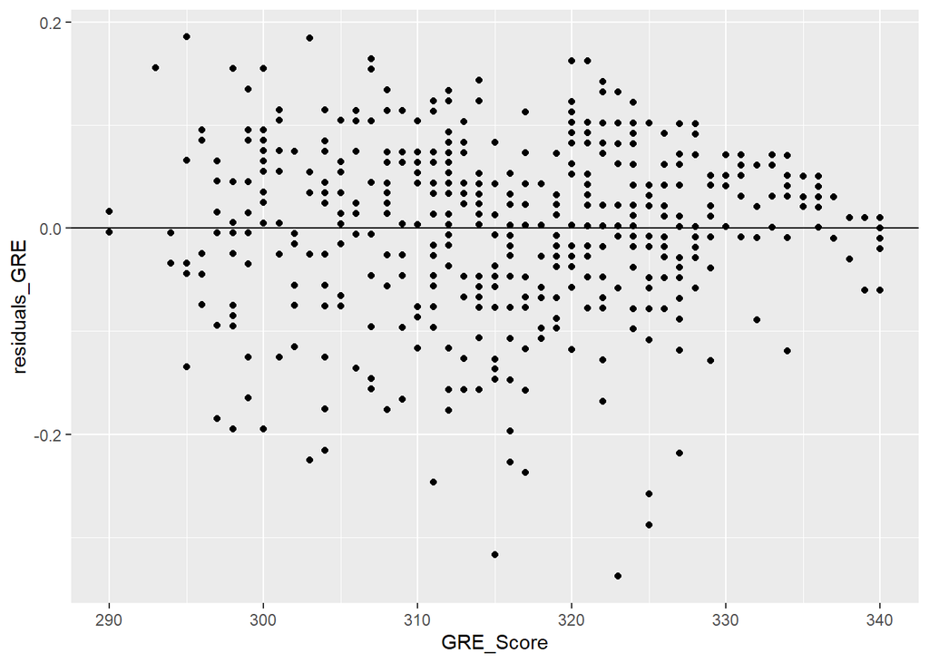

```r
ggplot(ga_test_GRE, aes(x = GRE_Score, y = residuals_GRE)) +
  geom_point() +
  geom_hline(yintercept = 0)
```

> There is no apparent pattern in the residual plot above. This means that a linear model is appropriate to describe the relationship between Chance_of_Admit and GRE_Score, that is, the condition of “linearity” has been met.

> Nearly normal residuals: To check this condition, we can look at a histogram.

##### Plotting histogram of residuals_GRE

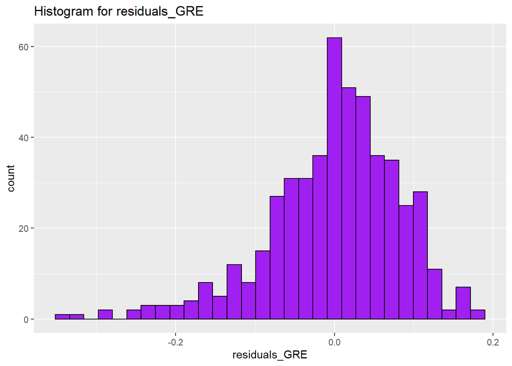

```r
ggplot(ga_test_GRE, aes(x = residuals_GRE)) +
   geom_histogram(fill = 'purple', colour = 'black') +
   ggtitle("Histogram for residuals_GRE")
```

##### Finding correct binwidth

```r
xx <- (max(ga_test_GRE$residuals_GRE) - min(ga_test_GRE$residuals_GRE))/30
xx
```

```
## [1] 0.01745084
```

##### Plotting Histogram for residuals_GRE with correct binwidth

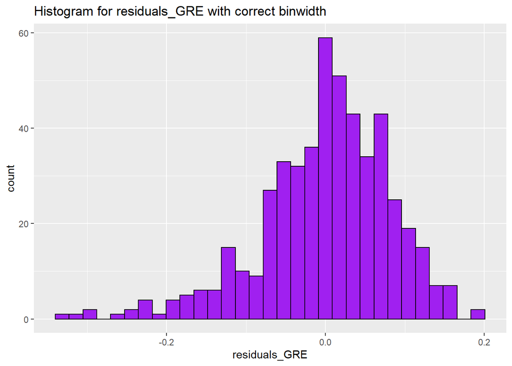

```r
ggplot(ga_test_GRE, aes(x = residuals_GRE)) +
   geom_histogram(fill = 'purple', colour = 'black', binwidth = 0.01745084) +
  ggtitle("Histogram for residuals_GRE with correct binwidth")
```

> Based on the histogram above, the residuals appear to be nearly normal so this condition is met.

##### To check Constant variability: I will redraw the plot in The Scatter plot of residuals_GRE vs GRE_Score with some extra horizontal lines:

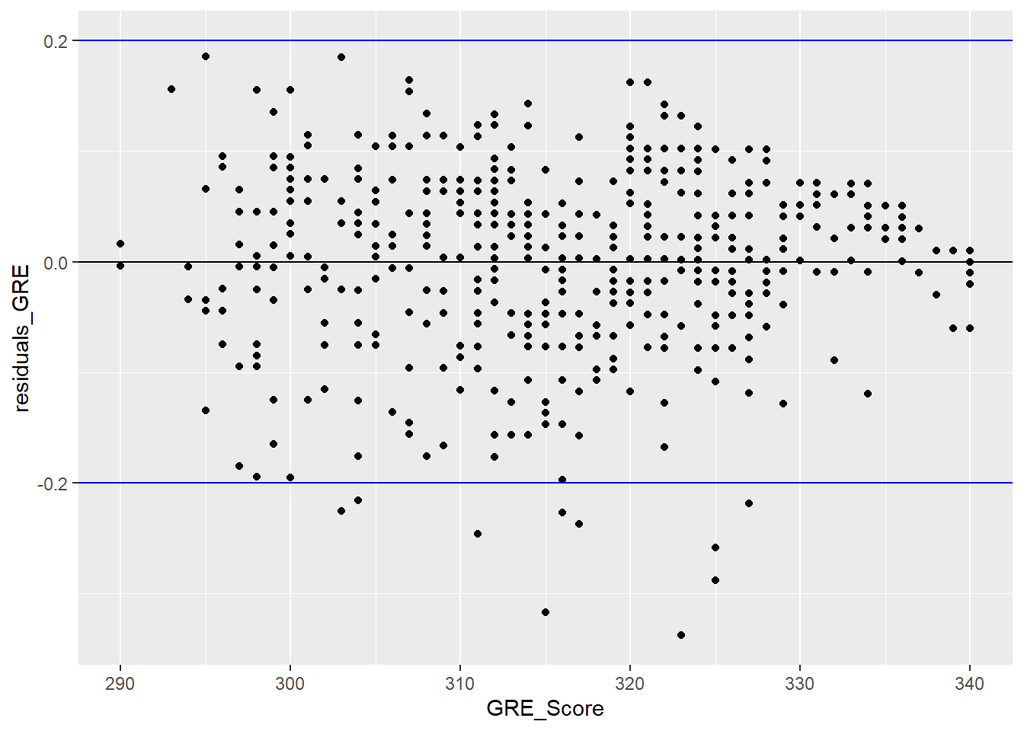

```r
ggplot(ga_test_GRE, aes(x = GRE_Score, y = residuals_GRE)) +
  geom_point() +
  geom_hline(yintercept = 0) +
  geom_hline(yintercept = 0.2, color = 'blue') +
  geom_hline(yintercept = -0.2, color = 'blue')
```

# Section 3 - Final analysis report and conclusion:

### Conclusion

I would like to conclude by saying that my hypothesis is correct and I have proven my hypothesis of saying that Chance of Admit increases with the GRE Score and CGPA. 0.0101259 times of the GRE Score and 0.20592 times of CGPA will give the chances of admit of a student in University. Once can find it by the best fit line equation that is: By GRE_Score:
$$\hat{y} = -2.4828147 + 0.0101259 * GREScore$$

By CGPA:
$$\hat{y} = -1.04434 + 0.20592 * CGPA$$

There are few things through which out prediction could get better that is using more then one variable to predict the Chance of Admit, I think that prediction can be done better by performing other models. Maybe taking 2 or 3 variables on one time to predict the Chance of Admit.

References : http://www.sthda.com/english/wiki/correlation-matrix-a-quick-start-guide-to-analyze-format-and-visualize-a-correlation-matrix-using-r-software (for corelation matrix)